# Project - Statiscal Methods for Decision Making

## Importing all the required libraries

```python
import numpy as np
import pandas as pd
from scipy.stats import f
import matplotlib.pyplot as plt
%matplotlib inline
import seaborn as sns
import scipy.stats as stats
from scipy.stats import ttest_1samp, ttest_ind, mannwhitneyu, levene, shapiro
from statsmodels.stats.power import ttest_power
```

Problem 1 A wholesale distributor operating in different regions of Portugal has information on annual spending of several items in their stores across different regions and channels. The data (Wholesale Customers Data.csv) consists of 440 large retailers’ annual spending on 6 different varieties of products in 3 different regions (Lisbon, Oporto, Other) and across different sales channel (Hotel/Restaurant/Café HoReCa, Retail).

## Loading the data set in python

```python
df=pd.read_csv('Wholesale+Customers+Data.csv')
df.head(5)
```

|  | Buyer/Spender | Channel | Region | Fresh | Milk | Grocery | Frozen | Detergents_Paper | Delicatessen |
| --- | --- | --- | --- | --- | --- | --- | --- | --- | --- |
| 0 | 1 | Retail | Other | 12669 | 9656 | 7561 | 214 | 2674 | 1338 |
| 1 | 2 | Retail | Other | 7057 | 9810 | 9568 | 1762 | 3293 | 1776 |
| 2 | 3 | Retail | Other | 6353 | 8808 | 7684 | 2405 | 3516 | 7844 |
| 3 | 4 | Hotel | Other | 13265 | 1196 | 4221 | 6404 | 507 | 1788 |
| 4 | 5 | Retail | Other | 22615 | 5410 | 7198 | 3915 | 1777 | 5185 |

Viewing the top 5 rows in the data

## Checking the summary of the data

```python
df.info()
```

[output not shown]

```python
df.describe(include='all').transpose() #Include all to include the categorical variables as well
```

|  | count | unique | top | freq | mean | std | min | 25% | 50% | 75% | max |
| --- | --- | --- | --- | --- | --- | --- | --- | --- | --- | --- | --- |
| Buyer/Spender | 440 | NaN | NaN | NaN | 220.5 | 127.161 | 1 | 110.75 | 220.5 | 330.25 | 440 |
| Channel | 440 | 2 | Hotel | 298 | NaN | NaN | NaN | NaN | NaN | NaN | NaN |
| Region | 440 | 3 | Other | 316 | NaN | NaN | NaN | NaN | NaN | NaN | NaN |
| Fresh | 440 | NaN | NaN | NaN | 12000.3 | 12647.3 | 3 | 3127.75 | 8504 | 16933.8 | 112151 |
| Milk | 440 | NaN | NaN | NaN | 5796.27 | 7380.38 | 55 | 1533 | 3627 | 7190.25 | 73498 |
| Grocery | 440 | NaN | NaN | NaN | 7951.28 | 9503.16 | 3 | 2153 | 4755.5 | 10655.8 | 92780 |
| Frozen | 440 | NaN | NaN | NaN | 3071.93 | 4854.67 | 25 | 742.25 | 1526 | 3554.25 | 60869 |
| Detergents_Paper | 440 | NaN | NaN | NaN | 2881.49 | 4767.85 | 3 | 256.75 | 816.5 | 3922 | 40827 |
| Delicatessen | 440 | NaN | NaN | NaN | 1524.87 | 2820.11 | 3 | 408.25 | 965.5 | 1820.25 | 47943 |

The function shows the mean, std deviation and other key details of the data

```python
df.info() #This function lets us see the no. of rows and columns, data type of each variable
```

[output not shown]

## Checking for missing values

```python
df.isnull().sum()
```

```
Buyer/Spender       0
Channel             0
Region              0
Fresh               0
Milk                0
Grocery             0
Frozen              0
Detergents_Paper    0
Delicatessen        0
dtype: int64
```

There are no missing values in the dataset

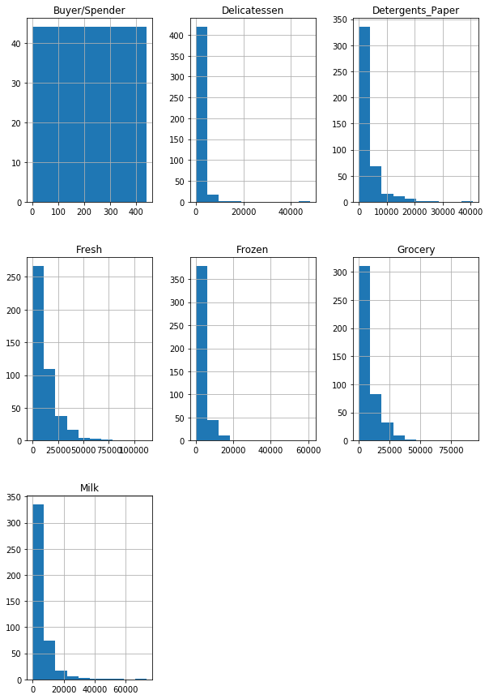

```python
df.hist(figsize=(10,15))
plt.show()
```

- All variable are highly skewed to the right.
- Buyer data is uniformaly distributed. This might be due the fact that it is nominal

## 1.1 Use methods of descriptive statistics to summarize data. Which Region and which Channel seems to spend more? Which Region and which Channel seems to spend less?

```python
#Calculating the total annual spend for each Buyer/Spender
df['Total']=df['Fresh']+df['Milk']+df['Grocery']+df['Frozen']+df['Detergents_Paper']+df['Delicatessen']
df.head(5)
```

|  | Buyer/Spender | Channel | Region | Fresh | Milk | Grocery | Frozen | Detergents_Paper | Delicatessen | Total |
| --- | --- | --- | --- | --- | --- | --- | --- | --- | --- | --- |
| 0 | 1 | Retail | Other | 12669 | 9656 | 7561 | 214 | 2674 | 1338 | 34112 |
| 1 | 2 | Retail | Other | 7057 | 9810 | 9568 | 1762 | 3293 | 1776 | 33266 |
| 2 | 3 | Retail | Other | 6353 | 8808 | 7684 | 2405 | 3516 | 7844 | 36610 |
| 3 | 4 | Hotel | Other | 13265 | 1196 | 4221 | 6404 | 507 | 1788 | 27381 |
| 4 | 5 | Retail | Other | 22615 | 5410 | 7198 | 3915 | 1777 | 5185 | 46100 |

```python
#Grouping the data by Region, so that it shows the the total value under each category for the respective regions
spend_reg=df.groupby(df['Region'],as_index=False)['Total'].sum().sort_values(by='Total',ascending=False)
spend_reg
```

|  | Region | Total |
| --- | --- | --- |
| 2 | Other | 10677599 |
| 0 | Lisbon | 2386813 |
| 1 | Oporto | 1555088 |

```python
spend_reg_chn=df.groupby([df['Channel'],df['Region']],as_index=False).sum().sort_values(by='Total',ascending=False)
spend_reg_chn
```

|  | Channel | Region | Buyer/Spender | Fresh | Milk | Grocery | Frozen | Detergents_Paper | Delicatessen | Total |
| --- | --- | --- | --- | --- | --- | --- | --- | --- | --- | --- |
| 2 | Hotel | Other | 48020 | 2928269 | 735753 | 820101 | 771606 | 165990 | 320358 | 5742077 |
| 5 | Retail | Other | 16006 | 1032308 | 1153006 | 1675150 | 158886 | 724420 | 191752 | 4935522 |
| 0 | Hotel | Lisbon | 14026 | 761233 | 228342 | 237542 | 184512 | 56081 | 70632 | 1538342 |
| 3 | Retail | Lisbon | 4069 | 93600 | 194112 | 332495 | 46514 | 148055 | 33695 | 848471 |
| 4 | Retail | Oporto | 5911 | 138506 | 174625 | 310200 | 29271 | 159795 | 23541 | 835938 |
| 1 | Hotel | Oporto | 8988 | 326215 | 64519 | 123074 | 160861 | 13516 | 30965 | 719150 |

```python
#Grouping the data by Channel, so that it shows the the total value under each category for the respective Channels
spend_channel=df.groupby(df['Channel'], as_index=False)["Total"].sum().sort_values(by='Total',ascending=False)
spend_channel
```

|  | Channel | Total |
| --- | --- | --- |
| 0 | Hotel | 7999569 |
| 1 | Retail | 6619931 |

```python
#Grouping data by Channel and Region
grouped=df.groupby(['Channel','Region'],as_index=False)['Total'].sum().sort_values(by="Total", ascending=False)
grouped
```

|  | Channel | Region | Total |
| --- | --- | --- | --- |
| 2 | Hotel | Other | 5742077 |
| 5 | Retail | Other | 4935522 |
| 0 | Hotel | Lisbon | 1538342 |
| 3 | Retail | Lisbon | 848471 |
| 4 | Retail | Oporto | 835938 |
| 1 | Hotel | Oporto | 719150 |

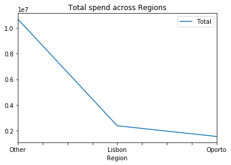

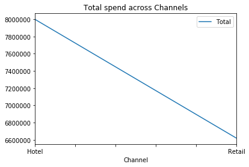

```python
#Graphical view of amount spent vs. Region
spend_reg.plot(x='Region', y='Total',kind = 'line')
plt.title('Total spend across Regions')
plt.show()
#Graphical view of amount spent vs. Channel
spend_channel.plot(x='Channel', y='Total',kind = 'line')
plt.title('Total spend across Channels')
plt.show()
```

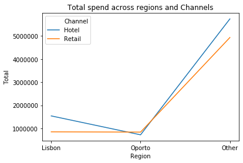

```python
#Graphical view of Spend over regions, with hue of Channel
ax=sns.lineplot(x='Region', y='Total',data=grouped,hue='Channel')
plt.title('Total spend across regions and Channels')
plt.show()
```

## 1.2 There are 6 different varieties of items are considered. Do all varieties show similar behaviour across Region and Channel?

```python
region=df.groupby(['Region'],as_index=False).sum().sort_values(by="Total", ascending=False)
region
```

|  | Region | Buyer/Spender | Fresh | Milk | Grocery | Frozen | Detergents_Paper | Delicatessen | Total |
| --- | --- | --- | --- | --- | --- | --- | --- | --- | --- |
| 2 | Other | 64026 | 3960577 | 1888759 | 2495251 | 930492 | 890410 | 512110 | 10677599 |
| 0 | Lisbon | 18095 | 854833 | 422454 | 570037 | 231026 | 204136 | 104327 | 2386813 |
| 1 | Oporto | 14899 | 464721 | 239144 | 433274 | 190132 | 173311 | 54506 | 1555088 |

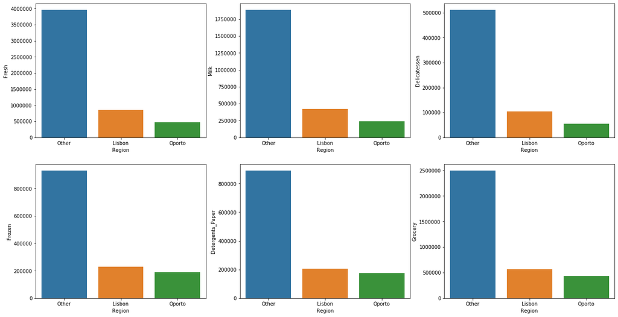

```python
# Plotting bar chart for each category to view the behaviour of all 6 items across Regions
plt.figure(figsize=(21,11))
axes = plt.axes()
axes.set_ylim([0,4000000])
plt.subplot(2,3,1)
sns.barplot(region['Region'], region['Fresh'])
plt.subplot(2,3,2)
sns.barplot(region['Region'], region['Milk'])
plt.subplot(2,3,6)
sns.barplot(region['Region'], region['Grocery'])
plt.subplot(2,3,4)
sns.barplot(region['Region'], region['Frozen'])
plt.subplot(2,3,5)
sns.barplot(region['Region'], region['Detergents_Paper'])
plt.subplot(2,3,3)
sns.barplot(region['Region'], region['Delicatessen'])
plt.show()
```

We can see from the bar plots above that all 6 varieties of items have the same behaviour across regions however each vairable individually does not behave the same way over regions. The highest annual spend is in Other region for all variables. The spend in Lisbon and Oporto is much lesser as compared to Other region, however the spend in Lisbon is higher than Oporto.

```python
channel=df.groupby(['Channel'],as_index=False).sum().sort_values(by="Total", ascending=False)
channel
```

|  | Channel | Buyer/Spender | Fresh | Milk | Grocery | Frozen | Detergents_Paper | Delicatessen | Total |
| --- | --- | --- | --- | --- | --- | --- | --- | --- | --- |
| 0 | Hotel | 71034 | 4015717 | 1028614 | 1180717 | 1116979 | 235587 | 421955 | 7999569 |
| 1 | Retail | 25986 | 1264414 | 1521743 | 2317845 | 234671 | 1032270 | 248988 | 6619931 |

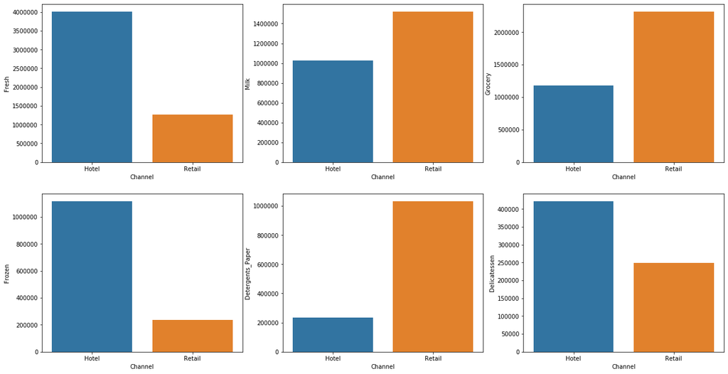

```python
plt.figure(figsize=(21,11))
plt.subplot(2,3,1)
sns.barplot(channel['Channel'], channel['Fresh'])
plt.subplot(2,3,2)
sns.barplot(channel['Channel'], channel['Milk'])
plt.subplot(2,3,3)
sns.barplot(channel['Channel'], channel['Grocery'])
plt.subplot(2,3,4)
sns.barplot(channel['Channel'], channel['Frozen'])
plt.subplot(2,3,5)
sns.barplot(channel['Channel'], channel['Detergents_Paper'])
plt.subplot(2,3,6)
sns.barplot(channel['Channel'], channel['Delicatessen'])
plt.show()
```

Visually we can observe that the items do not have the same behaviour across channels. If we compare the behaviour of the variables with each other we can see that spend on items such as Milk, Grocery and Detergents_paper, follow the same behaviour across Channels where Retail has a much higher spend than Hotel. For the other 3 categories - Delicattessen, Fresh and Frozen, the opposite behaviour is exhibited wherein the spend in higher for the Hotel channel and lower for Retail

## 1.3 On the basis of the descriptive measure of variability, which item shows the most inconsistent behaviour? Which items shows the least inconsistent behaviour?

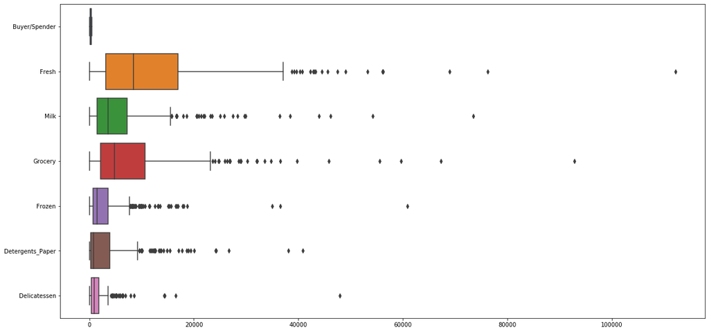

```python
#Plotting a box plot to identify which items show the most inconsistent behaviour
plt.figure(figsize=(20,10))
df_copy=df.copy() #Creating a copy of a file in order to not change the original dataset
df_copy.drop('Total',axis=1,inplace=True)
boxplot=sns.boxplot(data=df_copy, width=0.8,orient='h')
plt.show()
```

Variability can be measured by

- Range
- IQR
- Variance
- Std. Dev

We will comment on the IQR. Basis the boxplot above we can see that the category Fresh has the highest IQR. This means that Fresh category shows the least consistent behaviour

## 1.4 Are there any outliers in the data?

From the boxplot we can see that there are outliers amongst all the items

#### Problem 2

The Student News Service at Clear Mountain State University (CMSU) has decided to gather data about the undergraduate students that attend CMSU. CMSU creates and distributes a survey of 14 questions and receives responses from 62 undergraduates (stored in the Survey.csv file).

```python
#Loading the file into Python
df2=pd.read_csv('Survey.csv')
df2.head(5) #Viewing the top 5 rows of the data
```

|  | ID | Gender | Age | Class | Major | Grad Intention | GPA | Employment | Salary | Social Networking | Satisfaction | Spending | Computer | Text Messages |
| --- | --- | --- | --- | --- | --- | --- | --- | --- | --- | --- | --- | --- | --- | --- |
| 0 | 1 | Female | 20 | Junior | Other | Yes | 2.9 | Full-Time | 50.0 | 1 | 3 | 350 | Laptop | 200 |
| 1 | 2 | Male | 23 | Senior | Management | Yes | 3.6 | Part-Time | 25.0 | 1 | 4 | 360 | Laptop | 50 |
| 2 | 3 | Male | 21 | Junior | Other | Yes | 2.5 | Part-Time | 45.0 | 2 | 4 | 600 | Laptop | 200 |
| 3 | 4 | Male | 21 | Junior | CIS | Yes | 2.5 | Full-Time | 40.0 | 4 | 6 | 600 | Laptop | 250 |
| 4 | 5 | Male | 23 | Senior | Other | Undecided | 2.8 | Unemployed | 40.0 | 2 | 4 | 500 | Laptop | 100 |

```python
df2.info()
```

```
<class 'pandas.core.frame.DataFrame'>
RangeIndex: 62 entries, 0 to 61
Data columns (total 14 columns):
ID                   62 non-null int64
Gender               62 non-null object
Age                  62 non-null int64
Class                62 non-null object
Major                62 non-null object
Grad Intention       62 non-null object
GPA                  62 non-null float64
Employment           62 non-null object
Salary               62 non-null float64
Social Networking    62 non-null int64
Satisfaction         62 non-null int64
Spending             62 non-null int64
Computer             62 non-null object
Text Messages        62 non-null int64
dtypes: float64(2), int64(6), object(6)
memory usage: 6.9+ KB
```

```python
df2.describe(include='all').transpose()
#Checking the summary of the data
```

|  | count | unique | top | freq | mean | std | min | 25% | 50% | 75% | max |
| --- | --- | --- | --- | --- | --- | --- | --- | --- | --- | --- | --- |
| ID | 62 | NaN | NaN | NaN | 31.5 | 18.0416 | 1 | 16.25 | 31.5 | 46.75 | 62 |
| Gender | 62 | 2 | Female | 33 | NaN | NaN | NaN | NaN | NaN | NaN | NaN |
| Age | 62 | NaN | NaN | NaN | 21.129 | 1.43131 | 18 | 20 | 21 | 22 | 26 |
| Class | 62 | 3 | Senior | 31 | NaN | NaN | NaN | NaN | NaN | NaN | NaN |
| Major | 62 | 8 | Retailing/Marketing | 14 | NaN | NaN | NaN | NaN | NaN | NaN | NaN |
| Grad Intention | 62 | 3 | Yes | 28 | NaN | NaN | NaN | NaN | NaN | NaN | NaN |
| GPA | 62 | NaN | NaN | NaN | 3.12903 | 0.377388 | 2.3 | 2.9 | 3.15 | 3.4 | 3.9 |
| Employment | 62 | 3 | Part-Time | 43 | NaN | NaN | NaN | NaN | NaN | NaN | NaN |
| Salary | 62 | NaN | NaN | NaN | 48.5484 | 12.0809 | 25 | 40 | 50 | 55 | 80 |
| Social Networking | 62 | NaN | NaN | NaN | 1.51613 | 0.844305 | 0 | 1 | 1 | 2 | 4 |
| Satisfaction | 62 | NaN | NaN | NaN | 3.74194 | 1.21379 | 1 | 3 | 4 | 4 | 6 |
| Spending | 62 | NaN | NaN | NaN | 482.016 | 221.954 | 100 | 312.5 | 500 | 600 | 1400 |
| Computer | 62 | 3 | Laptop | 55 | NaN | NaN | NaN | NaN | NaN | NaN | NaN |
| Text Messages | 62 | NaN | NaN | NaN | 246.21 | 214.466 | 0 | 100 | 200 | 300 | 900 |

```python
df2.isnull().sum()
# Checking for null values
```

```
ID                   0
Gender               0
Age                  0
Class                0
Major                0
Grad Intention       0
GPA                  0
Employment           0
Salary               0
Social Networking    0
Satisfaction         0
Spending             0
Computer             0
Text Messages        0
dtype: int64
```

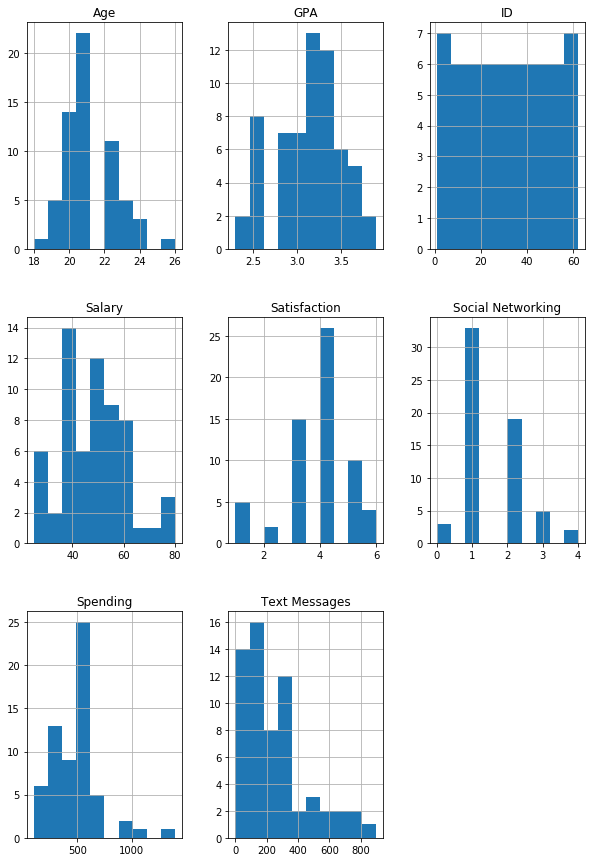

```python
# Looking at the distribution of the data
df2.hist(figsize=(10,15))
plt.show()
```

Interpretation of histogram

1. The distribution of Text messages is highly right skewed
2. The data for ID is nominal, hence we will not comment on the distribution
3. Satisfaction and Social Networking are categorical variables hence there are breaks in the histogram - Rating

## 2.1. For this data, construct the following contingency tables (Keep Gender as row variable)

- 2.1.1. Gender and Major
- 2.1.2. Gender and Grad Intention
- 2.1.3. Gender and Employment
- 2.1.4. Gender and Computer

#### 2.1.1. Gender and Major

```python
#Construction of contingency table for Gender and Majors
gender_major=pd.crosstab(df2['Gender'],df2['Major'],margins=True)
gender_major
```

| Major Gender | Accounting | CIS | Economics/Finance | International Business | Management | Other | Retailing/Marketing | Undecided | All |
| --- | --- | --- | --- | --- | --- | --- | --- | --- | --- |
| Female | 3 | 3 | 7 | 4 | 4 | 3 | 9 | 0 | 33 |
| Male | 4 | 1 | 4 | 2 | 6 | 4 | 5 | 3 | 29 |
| All | 7 | 4 | 11 | 6 | 10 | 7 | 14 | 3 | 62 |

#### 2.1.2. Gender and Grad Intention

```python
#Construction of contingency table for Gender and Grad Intention
gender_grad=pd.crosstab(df2['Gender'],df2['Grad Intention'],margins=True)
gender_grad
```

| Grad Intention Gender | No | Undecided | Yes | All |
| --- | --- | --- | --- | --- |
| Female | 9 | 13 | 11 | 33 |
| Male | 3 | 9 | 17 | 29 |
| All | 12 | 22 | 28 | 62 |

#### 2.1.3. Gender and Employment

```python
#Construction of contingency table for Gender and Employment
gender_emp=pd.crosstab(df2['Gender'],df2['Employment'],margins=True)
gender_emp
```

| Employment Gender | Full-Time | Part-Time | Unemployed | All |
| --- | --- | --- | --- | --- |
| Female | 3 | 24 | 6 | 33 |
| Male | 7 | 19 | 3 | 29 |
| All | 10 | 43 | 9 | 62 |

#### 2.1.4. Gender and Computer

```python
#Construction of contingency table for Gender and Computer
gender_comp=pd.crosstab(df2['Gender'],df2['Computer'],margins=True)
gender_comp
```

| Computer Gender | Desktop | Laptop | Tablet | All |
| --- | --- | --- | --- | --- |
| Female | 2 | 29 | 2 | 33 |
| Male | 3 | 26 | 0 | 29 |
| All | 5 | 55 | 2 | 62 |

## 2.2. Assume that the sample is a representative of the population of CMSU. Based on the data, answer the following questions:

## 2.2.1. What is the probability that a randomly selected CMSU student will be male? What is the probability that a randomly selected CMSU student will be female?

```python
# To find the probability we first calculate the total no. of Male and Female studetns
total=df2.groupby('Gender').count()
total
```

| Gender | ID | Age | Class | Major | Grad Intention | GPA | Employment | Salary | Social Networking | Satisfaction | Spending | Computer | Text Messages |
| --- | --- | --- | --- | --- | --- | --- | --- | --- | --- | --- | --- | --- | --- |
| Female | 33 | 33 | 33 | 33 | 33 | 33 | 33 | 33 | 33 | 33 | 33 | 33 | 33 |
| Male | 29 | 29 | 29 | 29 | 29 | 29 | 29 | 29 | 29 | 29 | 29 | 29 | 29 |

```python
#Pr(Male student)=No. of male/Total students
Total_male=29
Total_female=33
total_students=62
prob_male=round((Total_male/total_students),4)*100
prob_female=round((Total_female/total_students),4)*100
print('Probability of randomly selecting a male CMSU student is %1.1f' % prob_male +'%')
print('Probability of randomly selecting a female CMSU student is %1.1f' % prob_female +'%')
```

```
Probability of randomly selecting a male CMSU student is 46.8%
Probability of randomly selecting a female CMSU student is 53.2%
```

## 2.2.2. Find the conditional probability of different majors among the male students in CMSU. Find the conditional probability of different majors among the female students of CMSU.

```python
#Pr(Major|male), Pr(Major|Female)

#Accounting
account_male=4
account_female=3
prob_account_male=round((account_male/Total_male),4)*100
prob_account_female=round((account_female/Total_female),4)*100
print('Probability of Accounting major given a male CMSU student is %1.1f' % prob_account_male +'%')
print('Probability of Accounting major given a female CMSU student is %1.1f' % prob_account_female +'%')
```

```
Probability of Accounting major given a male CMSU student is 13.8%
Probability of Accounting major given a female CMSU student is 9.1%
```

```python
#CIS
CIS_male=1
CIS_female=3
prob_CIS_male=round((CIS_male/Total_male),4)*100
prob_CIS_female=round((CIS_female/Total_female),4)*100
print('Probability of CIS major given a male CMSU student is %1.1f' % prob_CIS_male +'%')
print('Probability of CIS major given a female CMSU student is %1.1f' % prob_CIS_female +'%')
```

```
Probability of CIS major given a male CMSU student is 3.5%
Probability of CIS major given a female CMSU student is 9.1%
```

```python
#Economincs and Finance
eco_male=4
eco_female=7
prob_eco_male=round((eco_male/Total_male),4)*100
prob_eco_female=round((eco_female/Total_female),4)*100
print('Probability of Economics and Finance major given a male CMSU student is %1.1f' % prob_eco_male +'%')
print('Probability of Economics and Finance major given a female CMSU student is %1.1f' % prob_eco_female +'%')
```

```
Probability of Economics and Finance major given a male CMSU student is 13.8%
Probability of Economics and Finance major given a female CMSU student is 21.2%
```

```python
#International Business
ib_male=2
ib_female=4
prob_ib_male=round((ib_male/Total_male),4)*100
prob_ib_female=round((ib_female/Total_female),4)*100
print('Probability of International Business major given a male CMSU student is %1.1f' % prob_ib_male +'%')
print('Probability of International Business major given a female CMSU student is %1.1f' % prob_ib_female +'%')
```

```
Probability of International Business major given a male CMSU student is 6.9%
Probability of International Business major given a female CMSU student is 12.1%
```

```python
#Management
mgmt_male=6
mgmt_female=4
prob_mgmt_male=round((mgmt_male/Total_male),4)*100
prob_mgmt_female=round((mgmt_female/Total_female),4)*100
print('Probability of Management major given a male CMSU student is %1.1f' % prob_mgmt_male +'%')
print('Probability of Management major given a female CMSU student is %1.1f' % prob_mgmt_female +'%')
```

```
Probability of Management major given a male CMSU student is 20.7%
Probability of Management major given a female CMSU student is 12.1%
```

```python
#Other
Other_male=4
Other_female=3
prob_Other_male=round((Other_male/Total_male),4)*100
prob_Other_female=round((Other_female/Total_female),4)*100
print('Probability of Other major given a male CMSU student is %1.1f' % prob_Other_male +'%')
print('Probability of Other major given a female CMSU student is %1.1f' % prob_Other_female +'%')
```

```
Probability of Other major given a male CMSU student is 13.8%
Probability of Other major given a female CMSU student is 9.1%
```

```python
#Retail Marketing
rm_male=5
rm_female=9
prob_rm_male=round((rm_male/Total_male),4)*100
prob_rm_female=round((rm_female/Total_female),4)*100
print('Probability of Retail marketing major given a male CMSU student is %1.1f' % prob_rm_male +'%')
print('Probability of Retail marketing major given a female CMSU student is %1.1f' % prob_rm_female +'%')
```

```
Probability of Retail marketing major given a male CMSU student is 17.2%
Probability of Retail marketing major given a female CMSU student is 27.3%
```

```python
#Undecided
undecided_male=3
undecided_female=0
prob_undecided_male=round((undecided_male/Total_male),4)*100
prob_undecided_female=round((undecided_female/Total_female),4)*100
print('Probability of undecided major given a male CMSU student is %1.1f' % prob_undecided_male +'%')
print('Probability of undecided major given a female CMSU student is %1.1f' % prob_undecided_female +'%')
```

```
Probability of undecided major given a male CMSU student is 10.3%
Probability of undecided major given a female CMSU student is 0.0%
```